# Lab 6 for Intorduction to computational finance

# Task 1 Download the data and calculate the returns

- Make sure that you understand the code on the right and click ‘Submit Answer’ to run the code and start the lab.

```r
library(tseries)
library(PerformanceAnalytics)
```

```r
VBLTX_prices <- get.hist.quote(instrument="vbltx", start="2005-09-01", end="2010-09-30", quote="AdjClose",provider="yahoo", origin="1970-01-01",compression="m", retclass="zoo", quiet = TRUE)
FMAGX_prices <- get.hist.quote(instrument="fmagx", start="2005-09-01", end="2010-09-30", quote="AdjClose",provider="yahoo", origin="1970-01-01",compression="m", retclass="zoo", quiet = TRUE)
SBUX_prices <- get.hist.quote(instrument="sbux", start="2005-09-01",end="2010-09-30", quote="AdjClose",provider="yahoo", origin="1970-01-01",compression="m", retclass="zoo", quiet = TRUE)

# Change the class of the time index to yearmon, which is appropriate for monthly data.
# index() and as.yearmon() are functions in the zoo package
index(VBLTX_prices) <- as.yearmon(index(VBLTX_prices))
index(FMAGX_prices) <- as.yearmon(index(FMAGX_prices))
index(SBUX_prices) <- as.yearmon(index(SBUX_prices))

# Create merged price data
all_prices <- merge(VBLTX_prices, FMAGX_prices, SBUX_prices)
# Rename columns
colnames(all_prices) <- c("VBLTX", "FMAGX", "SBUX")

# Calculate cc returns as difference in log prices
all_returns <- diff(log(all_prices))

# Create matrix with returns
return_matrix <- coredata(all_returns)
```

# Task 2 The standard error of the variances

- Assign to n_obs the number of observations in the matrix return_matrix.
- Assign to sigma2hat_vals the estimates of $σ_{i}^{2}$ for the three different assets.
- Assign to se_sigma2hat the estimates of $SE(σ^{2}_{i})$ and print the result to the console.

```r
# The variable return_matrix is preloaded in your workspace

# Number of observations
n_obs <- nrow(return_matrix)

# Estimates of sigma2hat
sigma2hat_vals <- apply(return_matrix, MARGIN = 2, FUN = var)

# Standard Error of sigma2hat
se_sigma2hat <- sigma2hat_vals/sqrt(n_obs/2)

se_sigma2hat
```

```
##        VBLTX        FMAGX         SBUX
## 0.0001577485 0.0008234650 0.0019598760
```

# Task 3 Estimate the standard error of the correlation parameter

- Assign to cor_matrix the correlation matrix of the returns.
- Assign to rhohat_vals the estimates of the correlations between “VBLTX,FMAGX”,“VBLTX,SBUX”,“FMAGX,SBUX”.
- Assign to se_rhohat the estimates of $SE(\rho^{2}_{ij})$ and print the result to the console.

```r
# Calculate the correlation matrix
cor_matrix <- cor(return_matrix)

# Get the lower triangular part of that 'cor_matrix'
rhohat_vals <- cor_matrix[lower.tri(cor_matrix)]

# Set the names
names(rhohat_vals) <- c("VBLTX,FMAGX","VBLTX,SBUX","FMAGX,SBUX")

# Compute the estimated standard errors for correlation
se_rhohat <- (1-rhohat_vals^2)/sqrt(n_obs)

se_rhohat
```

```
## VBLTX,FMAGX  VBLTX,SBUX  FMAGX,SBUX
##  0.12456486  0.12672855  0.08057816
```

# Task 4 Hypothesis test for the mean

- Use the t.test to perform the t-test for μVBLTX and print the result to the console. What do you conclude?

```r
t.test(all_returns[,1],mu = 0)
```

```
##
##  One Sample t-test
##
## data:  all_returns[, 1]
## t = 1.5541, df = 59, p-value = 0.1255
## alternative hypothesis: true mean is not equal to 0
## 95 percent confidence interval:
##  -0.001695998  0.013490703
## sample estimates:
##   mean of x
## 0.005897352
```

# Task 5 Interpretation of the hypothesis test for the mean

```r
t.test(all_returns[,2],mu = 0)
```

```
##
##  One Sample t-test
##
## data:  all_returns[, 2]
## t = -0.0931, df = 59, p-value = 0.9261
## alternative hypothesis: true mean is not equal to 0
## 95 percent confidence interval:
##  -0.01815639  0.01654152
## sample estimates:
##     mean of x
## -0.0008074391
```

# Task 6 Hypothesis test for the correlation

- Use the cor.test() function to test whether the correlation between the returns of “VBLTX” and “FMAGX” is significantly different from zero. What do you conclude?

```r
cor.test(x = all_returns[,1], y = all_returns[,2])
```

```
##
##  Pearson's product-moment correlation
##
## data:  all_returns[, 1] and all_returns[, 2]
## t = 1.4531, df = 58, p-value = 0.1516
## alternative hypothesis: true correlation is not equal to 0
## 95 percent confidence interval:
##  -0.06983202  0.42129159
## sample estimates:
##      cor
## 0.187416
```

# Task 7 Interpretation of the hypothesis test for correlation

```r
cor.test(x = all_returns[,1], y = all_returns[,3])
```

```
##
##  Pearson's product-moment correlation
##
## data:  all_returns[, 1] and all_returns[, 3]
## t = -1.0417, df = 58, p-value = 0.3019
## alternative hypothesis: true correlation is not equal to 0
## 95 percent confidence interval:
##  -0.3764866  0.1226273
## sample estimates:
##        cor
## -0.1355172
```

# Task 8 Normality of the asset returns

- Use the jarque.bera.test to test the normality of the “VBLTX” returns and print the output to the console. What do you conclude?

```r
jarque.bera.test(all_returns[,1])
```

```
##
##  Jarque Bera Test
##
## data:  all_returns[, 1]
## X-squared = 22.2581, df = 2, p-value = 1.468e-05
```

# Task 9 Interpretation of the normality test

```r
jarque.bera.test(all_returns[,2])
```

```
##
##  Jarque Bera Test
##
## data:  all_returns[, 2]
## X-squared = 26.0011, df = 2, p-value = 2.259e-06
```

# Task 10 Bootstrapping

- Use the boot() function to generate 999 bootstrap samples based on the returns of VBLTX and assign the result to VBLTX_mean_boot.
- Plot the bootstrapped distribution of the mean and a QQ-plot. This can be done by applying the plot() function on the VBLTX_mean_boot that you have created in the previous step.

```r
library("boot")
# Function for bootstrapping sample mean:
mean_boot <- function(x, idx) {
  ans <- mean(x[idx])
  ans
}
# Construct VBLTX_mean_boot:
VBLTX_mean_boot <- boot(return_matrix[,"VBLTX"], statistic = mean_boot, R=999)
# Print the class of VBLTX_mean_boot
class(VBLTX_mean_boot)
```

```
## [1] "boot"
```

```r
# Print VBLTX_mean_boot
VBLTX_mean_boot
```

```
##
## ORDINARY NONPARAMETRIC BOOTSTRAP
##
##
## Call:
## boot(data = return_matrix[, "VBLTX"], statistic = mean_boot,
##     R = 999)
##
##
## Bootstrap Statistics :
##        original        bias    std. error
## t1* 0.005897352 -5.663827e-05 0.003865074
```

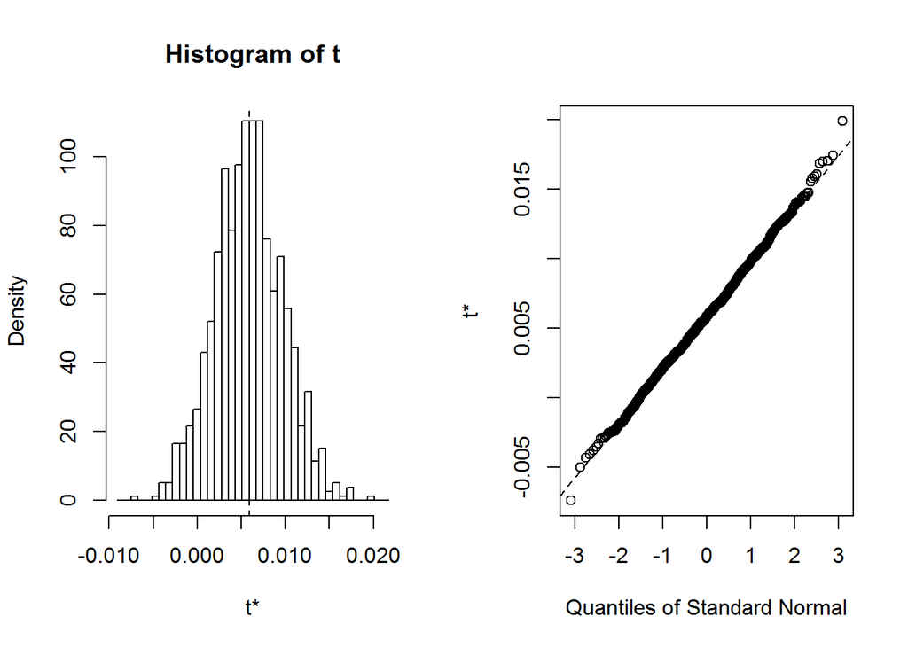

```r
# Plot bootstrap distribution and qq-plot against normal
plot(VBLTX_mean_boot)
```